# Stat 480 - Homework #8

3/8/2018

## Star Wars - Episode V

1. Download the RMarkdown file with these homework instructions to use as a template for your work. Make sure to replace “Your Name” in the YAML with your name.
2. We are back to investigating the Star Wars survey by FiveThirtyEight. We download and prep the data in the same way as last time:

```r
library(dplyr)
library(ggplot2)
library(readr)
starwars <- read_csv("https://raw.githubusercontent.com/fivethirtyeight/data/master/star-wars-survey/StarWars.csv")

# the following lines are necessary to make the second line of the file
# part of the names:
line1 <- names(starwars)
line2 <- unlist(starwars[1,])
varnames <- paste(line1, line2)
# clean up some of the multibyte characters:
names(starwars) <- enc2native(stringi::stri_trans_general(varnames, "latin-ascii"))

starwars <- starwars[-1,]
```

3. Variables 10 through 15 answer the question: “Please rank the Star Wars films in order of preference with 1 being your favorite film in the franchise and 6 being your least favorite film.” Use `gather` as shown in class to transform the data into a tidier format with new variables ‘movie’ and ‘ranking’. Save the result in a data frame called `ranks`.

```r
library(tidyr)
library(ggplot2)
```

```r
ranks <- starwars %>%
filter(`Have you seen any of the 6 films in the Star Wars franchise? Response`=="Yes") %>%  gather(key=movie, value=ranking, (10:15))

ranks <- ranks %>% mutate(
  ranking = as.numeric(ranking),
  movie = gsub(".*(Episode [VI]+).*", "\\1", movie)
) %>% select(`RespondentID NA`, movie, ranking) %>%
  arrange(`RespondentID NA`)
```

4. If participants are following the rules, each participant should give out a ranking of 1 through 6, for an overall sum of ranks of 21. Use the data frame `ranks` to check how many participants followed the rules. Those who didn’t - how did they not follow the rules?

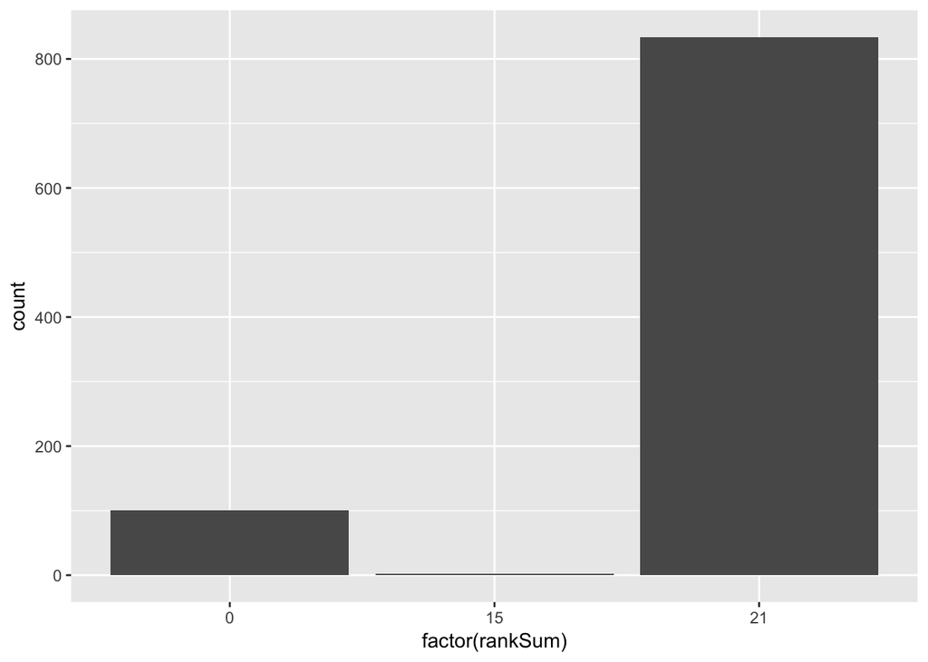

```r
part <- ranks %>% filter(`RespondentID NA`==3288372923)
rankSum = sum(part$ranking)

ranksSumm <- ranks %>% group_by(`RespondentID NA`) %>%
  summarize(rankSum = sum(ranking, na.rm=TRUE))

ranksSumm %>% ggplot(aes(x=factor(rankSum))) + geom_bar()
```

```r
off15 <- ranksSumm %>% filter(rankSum==15)
ranks %>% filter(`RespondentID NA` %in% off15$`RespondentID NA`)
```

```
## # A tibble: 12 x 3
##    `RespondentID NA` movie       ranking
##                <dbl> <chr>         <dbl>
##  1        3289450247 Episode I     NA
##  2        3289450247 Episode II     3.00
##  3        3289450247 Episode III    2.00
##  4        3289450247 Episode IV     5.00
##  5        3289450247 Episode V      1.00
##  6        3289450247 Episode VI     4.00
##  7        3290687830 Episode I      1.00
##  8        3290687830 Episode II     2.00
##  9        3290687830 Episode III   NA
## 10        3290687830 Episode IV     4.00
## 11        3290687830 Episode V      5.00
## 12        3290687830 Episode VI     3.00
```

```r
off0 <- ranksSumm %>% filter(rankSum==0)
ranks %>% filter(`RespondentID NA` %in% off0$`RespondentID NA`)
```

```
## # A tibble: 600 x 3
##    `RespondentID NA` movie       ranking
##                <dbl> <chr>         <dbl>
##  1        3288455900 Episode I        NA
##  2        3288455900 Episode II       NA
##  3        3288455900 Episode III      NA
##  4        3288455900 Episode IV       NA
##  5        3288455900 Episode V        NA
##  6        3288455900 Episode VI       NA
##  7        3288458873 Episode I        NA
##  8        3288458873 Episode II       NA
##  9        3288458873 Episode III      NA
## 10        3288458873 Episode IV       NA
## # ... with 590 more rows
```

```r
ranksSumm2 <- ranks %>% group_by(`RespondentID NA`)%>%
  mutate(rankSum = sum(ranking, na.rm=TRUE))
ranksSumm2 %>% filter(rankSum==21) %>% group_by(`RespondentID NA`) %>% tally()
```

```
## # A tibble: 834 x 2
##    `RespondentID NA`     n
##                <dbl> <int>
##  1        3288372923     6
##  2        3288373068     6
##  3        3288378779     6
##  4        3288388730     6
##  5        3288389603     6
##  6        3288391812     6
##  7        3288396374     6
##  8        3288398062     6
##  9        3288401136     6
## 10        3288401681     6
## # ... with 824 more rows
```

```r
ranksSumm3 <- ranks %>% group_by(`RespondentID NA`)%>%
  mutate(rankSum = sum(ranking, na.rm=TRUE))
ranksSumm3 %>% filter(rankSum==15) %>% group_by(`RespondentID NA`)
```

```
## # A tibble: 12 x 4
## # Groups:   RespondentID NA [2]
##    `RespondentID NA` movie       ranking rankSum
##                <dbl> <chr>         <dbl>   <dbl>
##  1        3289450247 Episode I     NA       15.0
##  2        3289450247 Episode II     3.00    15.0
##  3        3289450247 Episode III    2.00    15.0
##  4        3289450247 Episode IV     5.00    15.0
##  5        3289450247 Episode V      1.00    15.0
##  6        3289450247 Episode VI     4.00    15.0
##  7        3290687830 Episode I      1.00    15.0
##  8        3290687830 Episode II     2.00    15.0
##  9        3290687830 Episode III   NA       15.0
## 10        3290687830 Episode IV     4.00    15.0
## 11        3290687830 Episode V      5.00    15.0
## 12        3290687830 Episode VI     3.00    15.0
```

## Answer:

834 participants followed the rules. Some people had a sum of 0, so they might not have answered the question. Two participants had a sum of 15. the first person did not rank Episode I, while the second person didn’t rank Episode III.

5. Variables 16 through 29 answer the question on a character’s popularity between Very unfavorably to Very favorably. Gather all of these variables and create a long form of the data, introducing two new variables called `character` and `rating`. Save the result in a data frame called `popular`.

```r
popular <- starwars %>% filter(`Have you seen any of the 6 films in the Star Wars franchise? Response`=="Yes") %>%
  gather("character", "rating", 16:29)

popular
```

```
## # A tibble: 13,104 x 26
##    `RespondentID NA` `Have you seen aâ¦ `Do you considerâ¦ `Which of the foâ¦
##                <dbl> <chr>             <chr>             <chr>
##  1        3292879998 Yes               Yes               Star Wars: Episoâ¦
##  2        3292765271 Yes               No                Star Wars: Episoâ¦
##  3        3292763116 Yes               Yes               Star Wars: Episoâ¦
##  4        3292731220 Yes               Yes               Star Wars: Episoâ¦
##  5        3292719380 Yes               Yes               Star Wars: Episoâ¦
##  6        3292684787 Yes               Yes               Star Wars: Episoâ¦
##  7        3292663732 Yes               Yes               Star Wars: Episoâ¦
##  8        3292654043 Yes               Yes               Star Wars: Episoâ¦
##  9        3292640424 Yes               No                <NA>
## 10        3292637870 Yes               <NA>              <NA>
## # ... with 13,094 more rows, and 22 more variables: `X5 Star Wars: Episode
## #   II Attack of the Clones` <chr>, `X6 Star Wars: Episode III Revenge of
## #   the Sith` <chr>, `X7 Star Wars: Episode IV A New Hope` <chr>, `X8 Star
## #   Wars: Episode V The Empire Strikes Back` <chr>, `X9 Star Wars: Episode
## #   VI Return of the Jedi` <chr>, `Please rank the Star Wars films in
## #   order of preference with 1 being your favorite film in the franchise
## #   and 6 being your least favorite film. Star Wars: Episode I The Phantom
## #   Menace` <chr>, `X11 Star Wars: Episode II Attack of the Clones` <chr>,
## #   `X12 Star Wars: Episode III Revenge of the Sith` <chr>, `X13 Star
## #   Wars: Episode IV A New Hope` <chr>, `X14 Star Wars: Episode V The
## #   Empire Strikes Back` <chr>, `X15 Star Wars: Episode VI Return of the
## #   Jedi` <chr>, `Which character shot first? Response` <chr>, `Are you
## #   familiar with the Expanded Universe? Response` <chr>, `Do you consider
## #   yourself to be a fan of the Expanded Universe?ï¿½ï¿½ Response` <chr>, `Do
## #   you consider yourself to be a fan of the Star Trek franchise?
## #   Response` <chr>, `Gender Response` <chr>, `Age Response` <chr>,
## #   `Household Income Response` <chr>, `Education Response` <chr>,
## #   `Location (Census Region) Response` <chr>, character <chr>,
## #   rating <chr>
```

6. For the `popular` data frame, reorder the variable `rating` according to popularity from least popular to most popular. Change the level `Unfamiliar` to a missing value. Change the level “Please state whether you view the following characters favorably, unfavorably, or are unfamiliar with him/her. Han Solo” in the variable `character` to `Han Solo`.

```r
popular <- popular %>% mutate(
    rating = factor(rating, levels=c("Very unfavorably", "Somewhat unfavorably",
                                     "Neither favorably nor unfavorably (neutral)",
                                     "Somewhat favorably", "Very favorably",
                                     "Unfamiliar (N/A)")),
    rating = replace(rating, rating == "Unfamiliar (N/A)", NA),
    character = replace(character, character == "Please state whether you view the following characters favorably, unfavorably, or are unfamiliar with him/her. Han Solo", "Han Solo")
  )
```

7. For the modified `popular` data set, calculate average ratings for each of the characters (use scores 1 through 5 for the `rating` variable). Are men and women rating the characters differently? Plot average ratings by character, colour ratings by gender. Sort characters by overall popularity. Which character is the most liked, which the least? Are there characters with large differences in popularity between the genders?

[figure not shown]

```r
ave <- popular %>% group_by(character, `Gender Response`) %>%
  summarise(
    avg = mean(as.numeric(rating), na.rm=TRUE))

ave <- ave %>% ungroup(character)

ave <- ave %>% mutate(
    character=reorder(character, avg))

ave %>% ggplot(aes(x = character, y=avg, colour=`Gender Response`)) +
  geom_point() + coord_flip()
```

##Answer: Han Solo is the most liked while Jar Jar Binks is the least liked. R2 D2, C-3P0, Anakin Skywalker, and Boba Fett have a moderate difference between the genders. Darth Vader, Emperor Palpatine, and Jar Jar Binks had the greatest gender difference.

Due date: the homework is due before class on Thursday.

For the submission: submit your solution in an R Markdown file and (just for insurance) submit the corresponding html file with it.